# Aula 1: Usando o R Markdown

Rodrigo R Cardoso

12 de abril de 2019

## Introdução

### O que é Markdown?

O **Markdown** é uma linguagem de marcação leve que você pode usar para adicionar elementos de formatação a documentos de texto simples. Criado por John Gruber em 2004, o Markdown é hoje uma das linguagens de marcação mais populares do mundo.

O uso do Markdown é diferente de usar um editor WYSIWYG (OQVVEOQVO). Em um aplicativo como o Microsoft Word, você clica nos botões para formatar palavras e frases, e as alterações são visíveis imediatamente. Markdown não é assim. Quando você cria um arquivo formatado Markdown, adiciona a sintaxe Markdown ao texto para indicar quais palavras e frases devem ter uma aparência diferente.

### R Markdown

O formato de documento “R Markdown” foi introduzido pela primeira vez no pacote **knitr** (Xie 2015 , 2019 b) no início de 2012. A ideia era incorporar blocos de código (de R ou outras linguagens) em documentos Markdown.

A simplicidade do Markdown claramente se destaca dentre os formatos de documentos (LaTeX, HTML,…).

No entanto, a versão original do Markdown de John Gruber era frequentemente considerada excessivamente simples e inadequada para escrever documentos altamente técnicos. Por exemplo, não havia sintaxe para tabelas, notas de rodapé, expressões matemáticas ou citações. Felizmente, John MacFarlane criou um pacote maravilhoso chamado **Pandoc** para converter documentos Markdown (e muitos outros tipos de documentos) em uma grande variedade de formatos de saída.

Mais importante sobre o pandoc é que sintaxe do Markdown foi significativamente enriquecida. Agora podemos escrever mais tipos de elementos com o Markdown enquanto ainda desfrutamos da sua simplicidade.

Resumindo, o R Markdown está apoiado em um bipé, o **knitr** e o **Pandoc**. O primeiro executa o código de computador incorporado no Markdown e converte o R Markdown em Markdown. O último processa Markdown para o formato de saída desejado (como PDF, HTML, Word e assim por diante).

### O que o R Markdown pode fazer?

Neste momento, há um grande número de tarefas que você poderia fazer com o R Markdown:

- Compile um único documento R Markdown para um relatório em diferentes formatos, como PDF, HTML ou Word.
- Crie blocos de anotações nos quais você pode executar diretamente blocos de código interativamente.
- Faça slides para apresentações (HTML5, ioslides, LaTeX Beamer, PowerPoint).
- Produza dashboards com layouts flexíveis, interativos e atraentes.
- Crie aplicativos interativos baseados em Shiny.
- Escreva artigos de periódicos.
- Livros de autor de múltiplos capítulos.
- Gerar sites e blogs.

## Sintaxe do R Markdown

### Texto

- **Texto simples**

```
Lorem ipsum lacus donec aliquet dapibus eu aliquam vulputate neque, ac pellentesque donec nibh enim hendrerit vivamus donec, metus nam vehicula turpis duis bibendum mollis iaculis. elit integer dolor rhoncus justo commodo aliquam ullamcorper amet, eu vivamus enim primis aptent eu neque sapien, fringilla a auctor consectetur vivamus imperdiet rhoncus.
```

Lorem ipsum lacus donec aliquet dapibus eu aliquam vulputate neque, ac pellentesque donec nibh enim hendrerit vivamus donec, metus nam vehicula turpis duis bibendum mollis iaculis. elit integer dolor rhoncus justo commodo aliquam ullamcorper amet, eu vivamus enim primis aptent eu neque sapien, fringilla a auctor consectetur vivamus imperdiet rhoncus.

```
*itálico* e _itálico_
```

*itálico* e *itálico*

```
**negrito** e __negrito__
```

**negrito** e **negrito**

```
sobrescrito^2^
```

sobrescrito<sup>2</sup>

```
~~riscado~~
```

riscado

### Seções

```
# Seção
## Subseção
### Subsubseção
#### Subsub da subseção
##### Subsub da subsubseção
```

### Lista

```
* Lista sem numeração
    * sub-item A
* item B
 + sub-item B -- 1
 + sub-item B -- 2

1. Lista com numeração
2. item 2
 + sub-item 1
 + sub-item 2
```

- Lista sem numeração
  - sub-item A
- item B
  - sub-item B – 1
  - sub-item B – 2
1. Lista com numeração
2. item 2
   - sub-item 1
   - sub-item 2

### Tabela

```
Nome da coluna 1 | Nome da coluna 2
---------------- | -------------
Dados            | Dados
Dados            | Dados
```

| Nome da coluna 1 | Nome da coluna 2 |
| --- | --- |
| Dados | Dados |
| Dados | Dados |

### Equações

```
$$ A = \pi*r^{2} $$

$$ x=\frac{-b\pm\sqrt{b^2-4ac}}{2a} $$
```

$$A = \pi*r^{2}$$

$$x=\frac{-b\pm\sqrt{b^2-4ac}}{2a}$$

### Imagens

```
![](rstudio.png){width="15%"}

``{r, out.width='15%', echo=FALSE}
knitr::include_graphics('rstudio.png')
``
```

[figure not shown]

[figure not shown]

### Citações

```
> Citação de alguém.
```

> Citação de alguém.

### Código R

Blocos de códigos do R são incorporados ao documentos da seguinte forma:

````
```{r}
paste("Olá", "Mundo!")
```
````

```r
paste("Olá", "Mundo!")
```

```
## [1] "Olá Mundo!"
```

> Para Inserir o **Chunk** do R existe o atalho: CTRL + ALT + I

Exemplo de utilização dos chunks com o Markdown

````
```{r, warning=FALSE, message=FALSE}

# Carregar pacotes
library(tidyverse)

# Carregar os dados
data(mtcars)

# Mostrar a cara dos dados
head(mtcars)

# Calcular número de carros por cilindros
table(mtcars$cyl)

# Gerar gráfico do número de carros por cilindros
barplot(
  height = table(mtcars$cyl),
  main = "Número de Carros por Qtd. de cilindros.",
  ylab = "Número de Carros",
  xlab = "Qtd. de cilindros",
  col = "lightblue",
  border = "#104e8b"
  )


```
````

```r
# Carregar pacotes
library(tidyverse)

# Carregar os dados
data(mtcars)

# Mostrar a cara dos dados
head(mtcars)
```

```
##                    mpg cyl disp  hp drat    wt  qsec vs am gear carb
## Mazda RX4         21.0   6  160 110 3.90 2.620 16.46  0  1    4    4
## Mazda RX4 Wag     21.0   6  160 110 3.90 2.875 17.02  0  1    4    4
## Datsun 710        22.8   4  108  93 3.85 2.320 18.61  1  1    4    1
## Hornet 4 Drive    21.4   6  258 110 3.08 3.215 19.44  1  0    3    1
## Hornet Sportabout 18.7   8  360 175 3.15 3.440 17.02  0  0    3    2
## Valiant           18.1   6  225 105 2.76 3.460 20.22  1  0    3    1
```

```r
# Calcular número de carros por cilindros
table(mtcars$cyl)
```

```
##
##  4  6  8
## 11  7 14
```

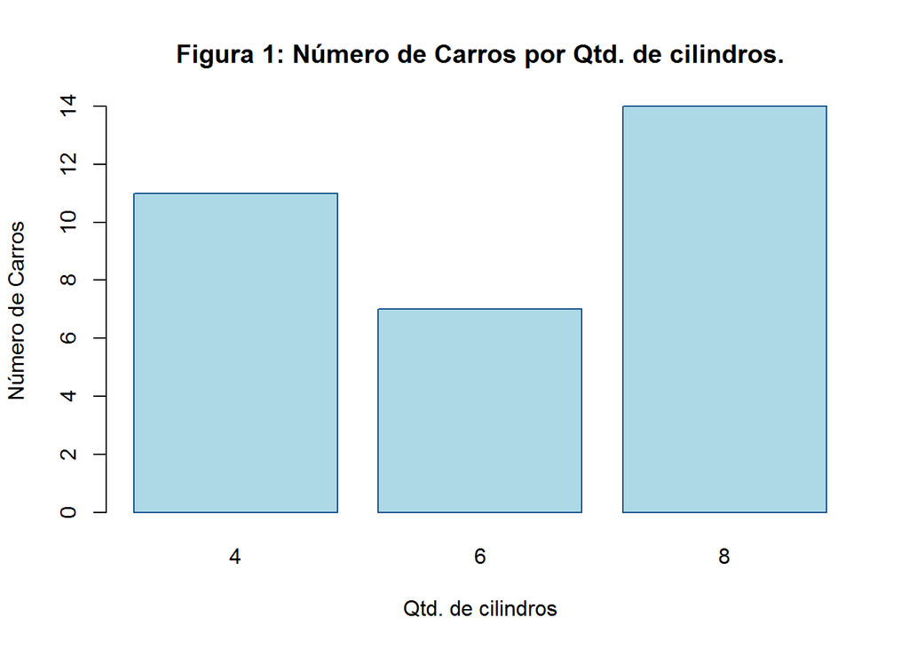

```r
# Gerar gráfico do número de carros por cilindros
barplot(
  height = table(mtcars$cyl),
  main = "Figura 1: Número de Carros por Qtd. de cilindros.",
  ylab = "Número de Carros",
  xlab = "Qtd. de cilindros",
  col = "lightblue",
  border = "#104e8b"
  )
```

Através da *Figura 1*, vemos que o **maior** número de carros (14) possuem 8 cilindros, e o **menor** número de carros (7) possuem 6 cilindros.

## Links Úteis

[Site - R Markdown](https://rmarkdown.rstudio.com/)

[Livro - R Markdown: The Definitive Guide](https://bookdown.org/yihui/rmarkdown/)

[R Markdown Reference Guide](https://www.rstudio.com/wp-content/uploads/2015/03/rmarkdown-reference.pdf)

[R Markdown Cheat Cheet](https://www.rstudio.org/links/r_markdown_cheat_sheet)

[Site - Producing Simple Graphs with R](https://www.harding.edu/fmccown/r/)

[Site - Bookdown](https://bookdown.org/)

## Referências

Xie, Yihui, J.J. Allaire, and Garrett Grolemund. 2018. R Markdown: The Definitive Guide. Boca Raton, Florida: Chapman; Hall/CRC. https://bookdown.org/yihui/rmarkdown.